# Problem Set 12

Aakash Ahuja

12/12/2019

**Ans1:** This is simply regression to the mean of the performance variable. Performance on the first maneuver is not perfectly correlated to the performance on the second maneuver after positive reinforcement. So Pilots who did the first maneuver pretty well might just regress to their average expected performance in the 2nd maneuver. This would make their performance look worse off than the last try. The pilots who didn’t do the first maneuver well might also regress to the mean performance. This would make their performance look better relatively. Regression explains this phenomenon well.

**Ans2: a)** Coefficient of determination or proportion of variance explained is square of correlation coefficient. We can also find it out using regression line.

```r
sister<-c(69, 64, 65, 63, 65, 62, 65, 64, 66, 59, 62)
brother<- c(71, 68, 66, 67, 70, 71, 70, 73, 72, 65, 66)
n<-length(sister)
slope<- cor(sister,brother)* (sd(brother)/sd(sister))
intercept<- mean(brother) - (slope*mean(sister))
yhat<- slope*sister+intercept
errors<-yhat-brother
final_df<-data.frame(cbind(sister,brother,yhat,errors))
proporation_variance_unexplained<- var(errors)/var(brother)
proporation_variance_explained<- 1-(var(errors)/var(brother))
proporation_variance_explained
```

```
## [1] 0.3114251
```

```r
(cor(sister,brother))^2
```

```
## [1] 0.3114251
```

We can see that ‘proporation_variance_explained’ and correlation coefficient square are the same.

**b)** Let the correlation coefficient be r between sister’s height and brother’s height.
$$H_0: p=0$$
$$H_1: p\neq0$$

```r
model1<-lm(brother~sister)
summary(model1)
```

```
##
## Call:
## lm(formula = brother ~ sister)
##
## Residuals:
##     Min      1Q  Median      3Q     Max
## -3.5909 -1.2273 -0.9545  1.1136  4.0000
##
## Coefficients:
##             Estimate Std. Error t value Pr(>|t|)
## (Intercept)  31.1818    18.7584   1.662   0.1308
## sister        0.5909     0.2929   2.018   0.0744 .
## ---
## Signif. codes:  0 '***' 0.001 '**' 0.01 '*' 0.05 '.' 0.1 ' ' 1
##
## Residual standard error: 2.379 on 9 degrees of freedom
## Multiple R-squared:  0.3114, Adjusted R-squared:  0.2349
## F-statistic:  4.07 on 1 and 9 DF,  p-value: 0.07442
```

**We can see that the p-value for this model is 0.07442. So we fail to reject our null hypothesis at significance level 0.05 that sister’s height helps predict brother’s height. We cannot predict brother’s height using sister’s height**

**c)**

```r
#Finding standard error for slope
se_slope<-(sd(brother)/sd(sister)) * sqrt((1-proporation_variance_explained)/(n-2))
#Finding original slope of line
slope_original<-coef(model1)[2]

#Finding T Statistic
T_stat<- (slope - slope_original)/se_slope

#Finding Confidence interval
upper<- slope + (qt(0.950, df=n-2)*se_slope)
lower<- slope - (qt(0.950, df=n-2)*se_slope)
ci<-c(lower,upper)
ci
```

```
## [1] 0.05401643 1.12780175
```

**So a 90% confidence interval for the slope of the Population Regression line for predicting brother’s height using sister’s height is (0.05401643,1.12780175)**

**Ans6:a)**

```r
exam<-read.table('examanxiety.txt', header = T)
slope<-cor(exam$Exam,exam$Anxiety) * (sd(exam$Exam)/sd(exam$Anxiety))
slope
```

```
## [1] -0.7300455
```

```r
intercept<- mean(exam$Exam) - (slope * mean(exam$Anxiety))
intercept
```

```
## [1] 111.2444
```

Therefore the equation is:
$$Y= (-0.7300455)*X + 111.2444$$

**Ans6:b)**

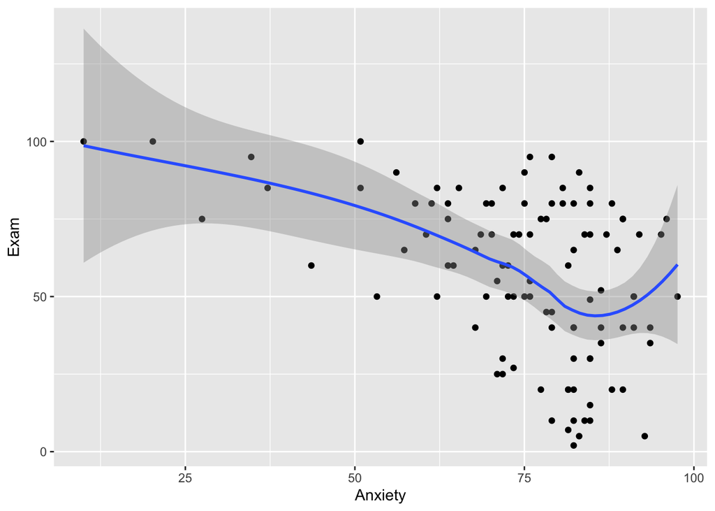

```r
#Checking Linearity:
library(ggplot2)
ggplot(exam, aes(x = Anxiety, y = Exam)) + geom_point() + geom_smooth() # This doesn't look like a linear relationship.
```

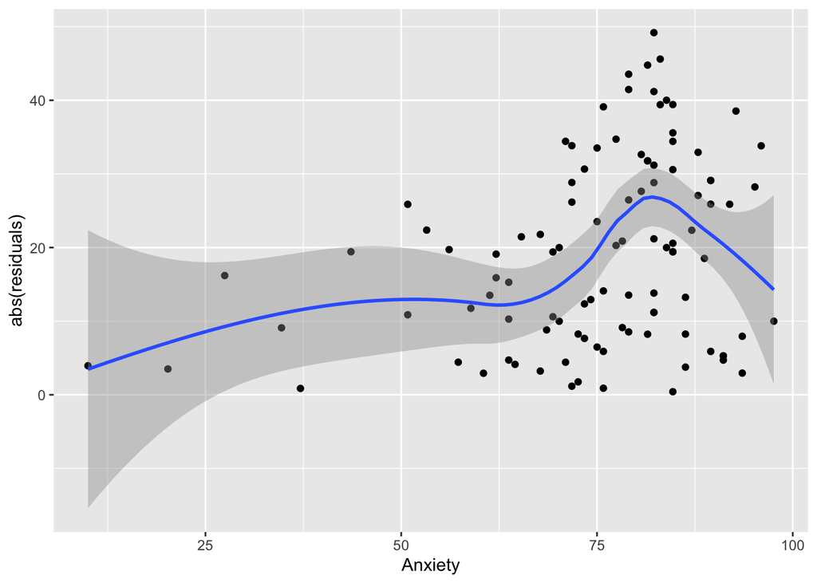

```r
#Checking Homoskedasticity
exam_data<-data.frame(cbind(Anxiety=exam$Anxiety,Exam=exam$Exam))
yhat<-slope*exam_data$Anxiety+intercept
exam_data$yhat<-yhat
residuals <- yhat - exam_data$Exam
exam_data$residuals<-residuals
ggplot(exam_data, aes(x = Anxiety, y = abs(residuals))) + geom_point() +geom_smooth()
```

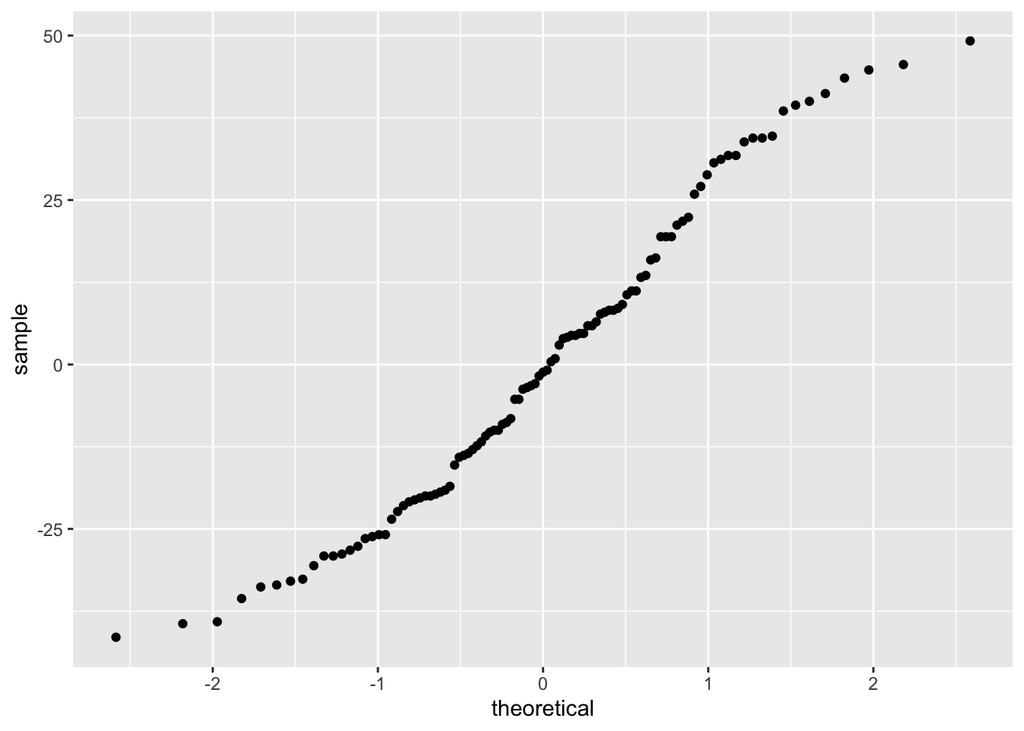

```r
#This is not at all flattish. So residuals do not all have equal variances.

#Checking Normality of errors:
ggplot(exam_data, aes(sample = residuals)) + stat_qq()
```

```r
#Here the data looks normal with no major outliers. With a large sample size of 103 we can assume that this assumption of normal residuals is met.
```

**So,the independence of errors assumption is met since the data samples were collected independently. Also the normality of errors assumption is met which is evident from the qqplot above.**